# Tawny owl in Kielder Forest

Seungyeon

2025-12-16

# Study area: Kielder Forest

Kielder Forest, the largest man-made forest in England, was established from the 1920s as a part of an afforestation programme for timber production (Figure 1). The forest ranges in elevation from 200 to 300 m, forming valleys around a large reservoir located at its centre. Once an open agricultural area, the landscape is now dominated by Sitka spruce (Picea sitchensis) followed by Norway spruce (Picea abies) (McIntosh, 1995). Under the current management regime, approximately 9000 ha year-1 of timber is harvested annually, with adjacent area left uncut for at least five years (McIntosh, 1995). These practices, coupled with 40 years of growing cycle required for these species to reach harvest maturity, have resulted in a dynamic, patchy landscape. The clear-felled area also provides suitable habitat for voles to thrive for at least five years following timber operations.  
The field vole (Microtus agrestis), which is most commonly found in grassland patches, is a key prey species supporting many predators in the Kielder Forest ecosystem. The abundance of field vole fluctuates on a 3-4 year cycle (Figure 2), shaping both population dynamics and intraguild prey-predator interaction. (Lambin et al., 2000,; Petty, 1992).

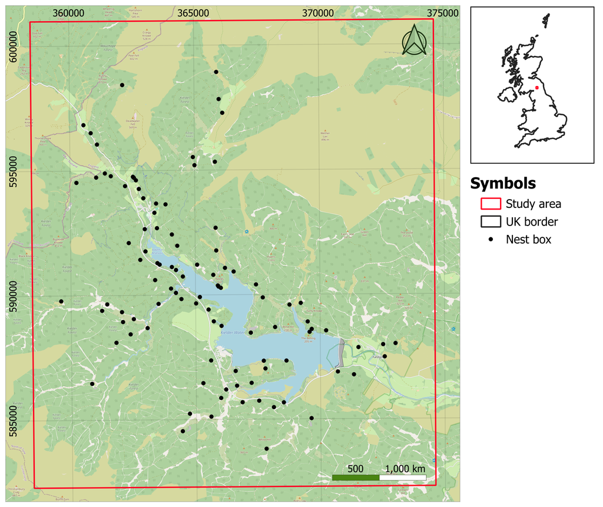

Figure 1. Location of Kielder Forest

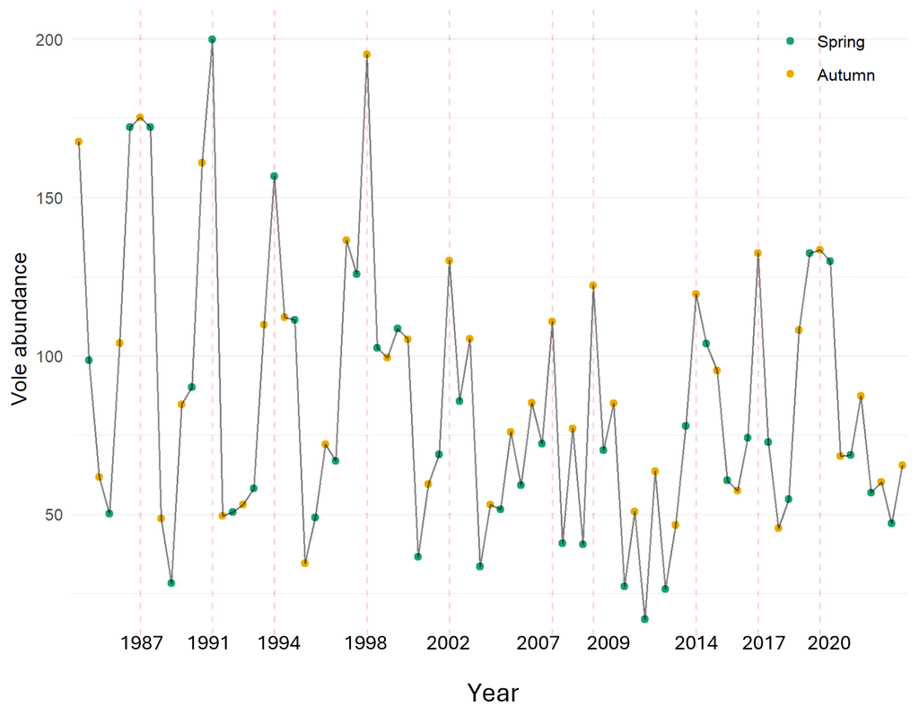

Figure 2. Trend in vole abundance (vole/ha) from 1985 to 2024. Green dots represent abundance estimates from spring survey, while yellow dots indicate results from autumn survey. Red dashed lines denote the boundaries of each vole population cycle.

First confirmed in 2018 in Kielder Forest, the Pine marten (Martes martes) is an opportunistic omnivore and is one of the meso-predators that primarily hunt field voles. As skilled tree climbers, pine martens are able to switch to alternative prey such as birds’ eggs, including those of owls, when rodent populations are low (Zárybnická et al., 2015). Studies have shown that pine martens memorise the locations of previously visited nest boxes (Sonerud, 1985, 2022) posing a threat to territorial raptors that rarely change nesting sites.

# Study system: Tawny owl

The Tawny owl (Strix aluco) is one of the most widespread raptors in the UK, typically inhabiting forests but can also be observed in parks or gardens. Rather than building their own nest, tawny owls depend on existing structure for breeding, which makes nest boxes a preferred option when available (Petty, 1992). As a highly sedentary and territorial raptor, juvenile tawny owls rarely disperse more than 4km from their natal sites (Martin & Mikkola, 2014) and seldom move their nests once they have established a breeding territory. Tawny owls primarily hunt within their territories (Southern, 1954), relying on intimate knowledge of their home range (Wardhaugh, 1984). Leaving their established territory is associated with a high risk of mortality (Hirons, 1985).

The annual lifecycle of tawny owls is divided mainly into three phases (Figure 3): Moulting, Breeding, and Wintering. The defence of territories begins in September when juveniles start to disperse while adults are still moulting their feathers. During the pre-breeding phase, males provide the majority of food to females. As such, the decision to breed is highly dependent on food availability, as females will only breed if they have gained sufficient weight to produce eggs (Hirons, 1985; Petty, 1999). Breeding typically occurs from late March to April, with clutch sizes ranging from two to five depending on the vole abundance. Most juveniles leave the natal box by the end of May, but they continue to receive food from their parents until August, after which they disperse from the natal area. Juveniles face a high risk of predation once they leave the nest box; however, most mortality is thought to result from starvation.

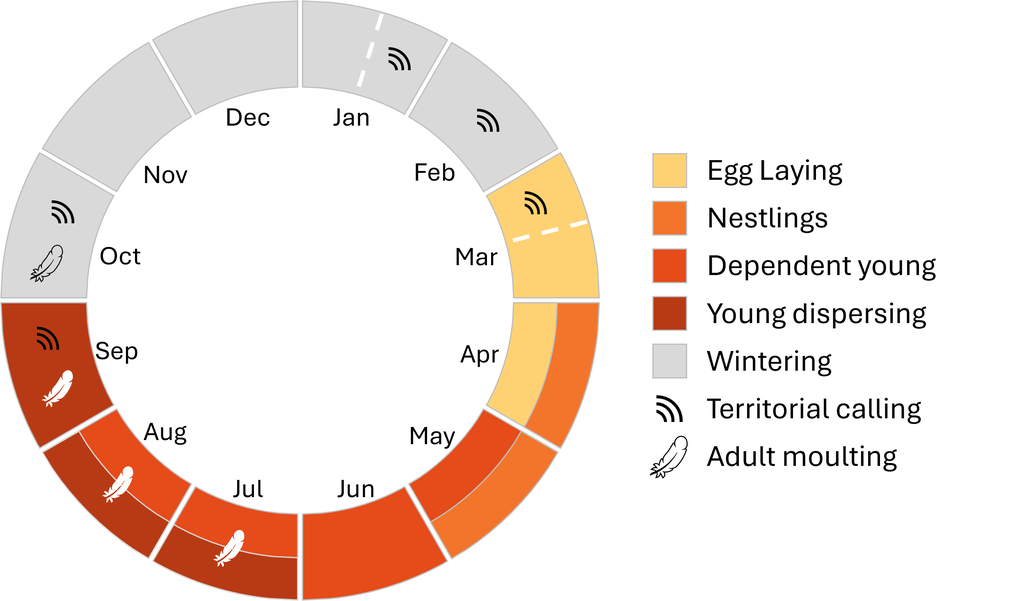

Figure 3. Annual cycle of Tawny owl (adapted from Petty, 1992). Dates may vary by the vole abundance.

Field voles are the primary prey of tawny owls during winter and spring, particularly in Kielder Forest. Although these owls can shift to alternative prey such as Common shrews (Sorex Araneus), or common frogs (Rana temporaria) and small birds during late spring and summer when field voles are scarce (Petty, 1999), their breeding success is thought to be highly dependent on vole density within their hunting territories. Despite their fluctuating productivity as a function of prey abundance, tawny owl populations have appeared stable over long periods (Hoy et al., 2016; Southern, 1970). Further, not only is breeding success related to the vole cycle, but so too is the age at first breeding (Millon et al., 2010). As females require enough food to initiate breeding, the floaters haven’t occupied the territory yet, or inexperienced hunters may have less chance to fulfil the requirements, which results in them staying as floaters. Many tawny owl floaters delay their first age of breeding until age three and can delay up to nine (Figure 4), and they are extremely difficult to detect with a general breeding bird survey.

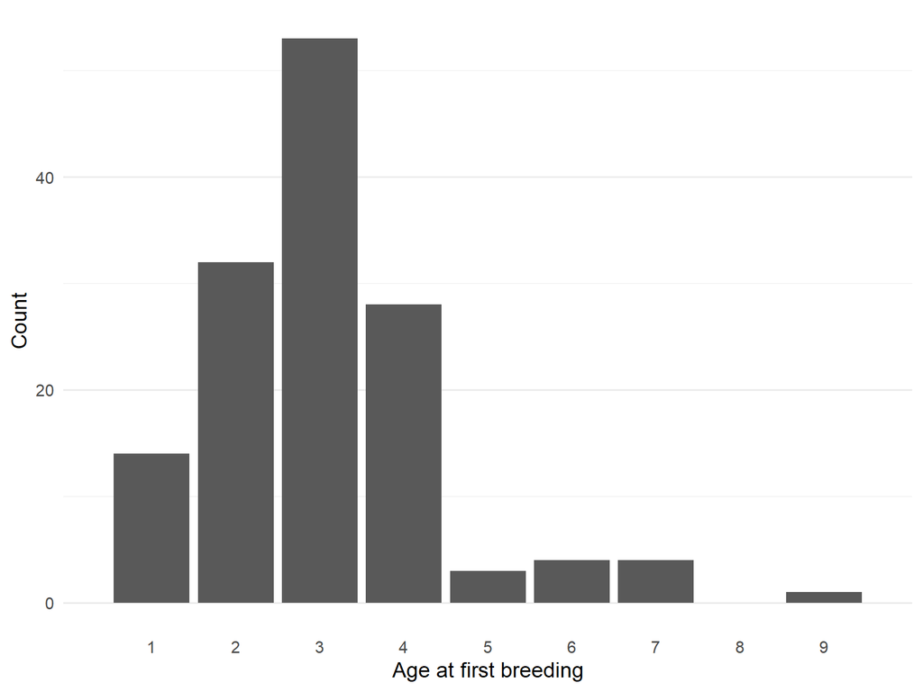

Figure 4. Distribution of age at first breeding of female tawny owl born in Kielder Centre from 1979 to 2024. Dates may vary by the vole abundance.

# Floater

The breeding status of tawny owls changes in response to vole abundance. During periods of high vole abundance, many tawny owls breed, making them easy to observe. In contrast, under low vole abundance, young fledglings often remain as floaters, and adults that previously bred and held territories may transition into a non-breeding state (Figure 5). Both floaters and non-breeders are undetectable in standard breeding bird surveys. Ten years ago, with the same study site, Million et al. (2014) showed that floater population might buffer the population; however, the low vole abundance might increase the risk of local extinction by increasing the high mortality of the floater. The vole cycle in the Kielder Forest is now facing low vole abundance compared to 20 years ago, with a somewhat ambiguous three to four-year cycle (Figure 2).

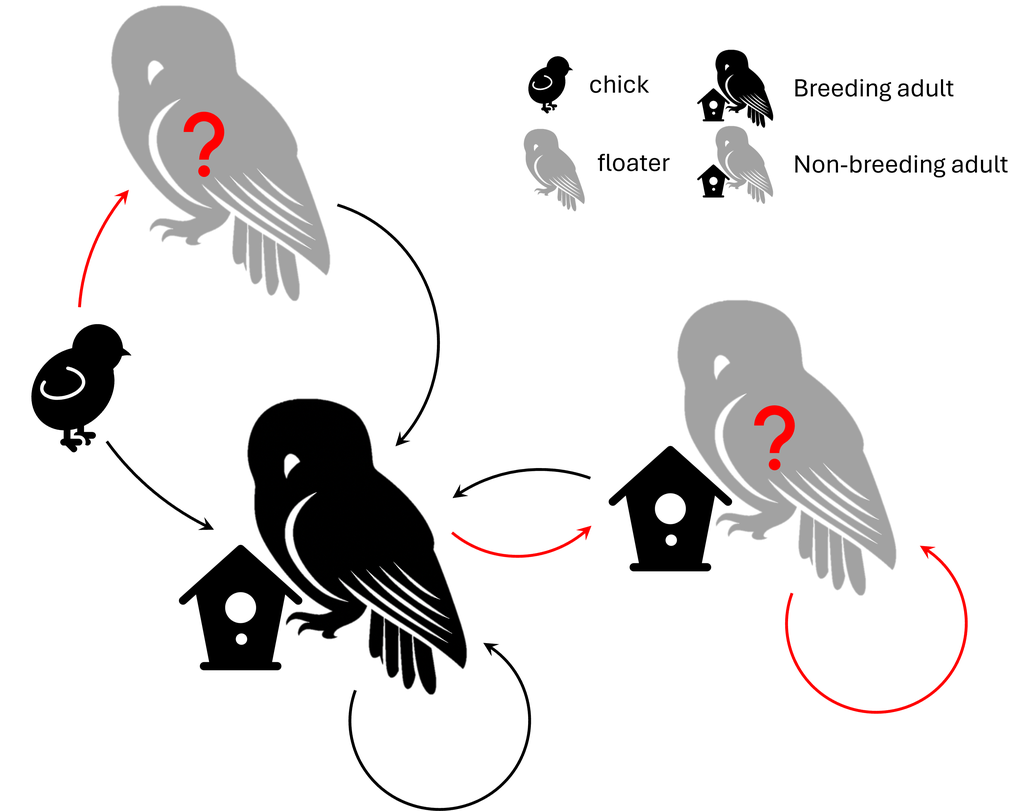